# 絶対値の話

mogobon

最終更新 2025-10-11

# 記号

- $\land$:「かつ」を表す論理記号である.
- $\lor$:「または」を表す論理記号である.
- $\mathbb{R}$: 実数全体の集合
- $\leq$: $\leqq$と同じである.
- $\geq$: $\geqq$と同じである.

# 絶対値の性質

## 準備

**Definition 1 (絶対値)**

実数$x$に対して, 絶対値$|x|$を次のように定義する.

$$\begin{equation}
|x| =
\begin{cases}
x~~~&(x\geq0)\\
-x~~~&(x<0)
\end{cases}
\end{equation}$$

**$y=|x|$のグラフ**

- 関数$y=|x|$のグラフを描画する.

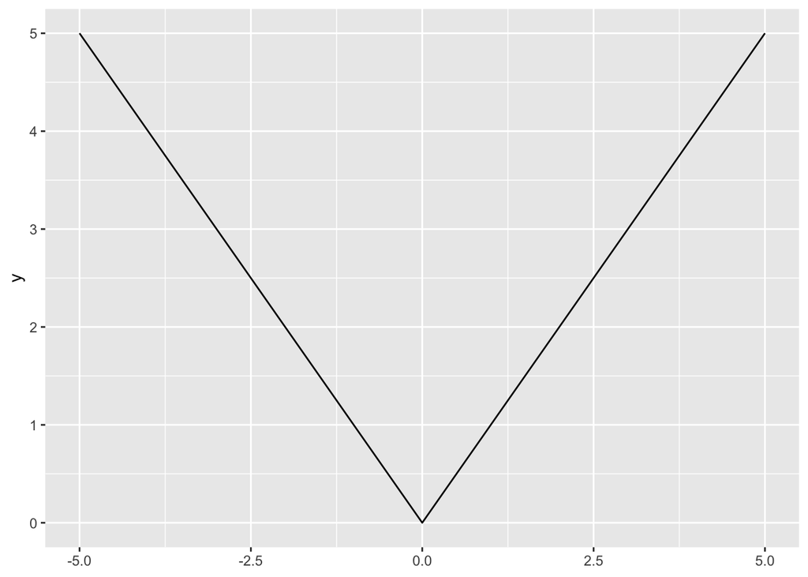

```r
base <- ggplot() +
  xlim(-5, 5) +
  geom_function(fun = abs)
base
```

### 絶対値と$\max$関数

**Proposition 1 (絶対値と$\max$関数)** 任意の実数$x$に対して, 次が成り立つ.

$$|x|=\max(\{x,-x\})$$

**証明**

*Proof*.

- $x\geq0$の場合
  - $\text{(左辺)}=|x|=x$が成り立つ.
  - $x\geq-x$より, $\text{(右辺)}=\max(\{x,-x\})=x$が成り立つ.
  - よって, $|x|=\max(\{x,-x\})$が成り立つ.
- $x<0$の場合
  - $\text{(左辺)}=|x|=-x$が成り立つ.
  - $-x> x$より, $\text{(右辺)}=\max(\{x,-x\})=-x$が成り立つ.
  - よって, $|x|=\max(\{x,-x\})$が成り立つ.

**証明に関する補足**

**補足**

### 絶対値の非負性

**Proposition 2 (絶対値の非負性)** 任意の$x\in\mathbb{R}$に対して, 次が成り立つ.

$$|x|\geq 0$$

**証明**

*Proof*.

- $x\geq 0$のとき, $|x|=x\geq 0$が成り立つ.
- $x<0$のとき, $|x|=-x=-(x)\geq0$が成り立つ.

**補足**

**注意**

- 上で, $x<0$の場合, $|x|\geq 0\Longleftrightarrow |x|>0\lor |x|=0$であり, $|x|=0$は偽であるが, $|x|>0$は真であるから, $|x|\geq 0$が成り立つ.
- 絶対値の中身が多変数になっている場合は, 複雑に見えるが, 冷静に考えよう.
- 例えば, 以下は誤りである.

**誤り**

$$\begin{align*}
|x-y|&=
\begin{cases}
x-y~~~&(x\geq0,~y>0)\\
x+y~~~&(x\geq0,~y<0)\\
-x-y~~~&(x<0,~y\geq0)\\
-x+y~~~&(x<0,~y<0)
\end{cases}\\
\end{align*}$$

- 場合わけする理由は, **絶対値の中身全体**が正と負の場合とで表現が異なるからである.
- 冷静に, 全体を捉えよう.

**Proposition 3 (絶対値の2乗と元の数の2乗は同じ)** 任意の$x\in\mathbb{R}$に対して, 次が成り立つ.
$$|x|^2=x^2$$

**証明**

*Proof*.

- $x\geq0$の場合
  - $|x|=x$より, $|x|^2=(|x|)^2=(x)^2=x^2$が成り立つ.
- $x<0$の場合
  - $|x|=-x$より, $|x|^2=(|x|)^2=(-x)^2=x^2$が成り立つ.

### 絶対値を含む基本的な不等式

**Proposition 4 (絶対値による評価)** 任意の$x\in\mathbb{R}$に対して, 次が成り立つ.
$$-|x|\leq x\leq |x|$$

**証明**

*Proof*.

**Proposition 5 (絶対値を含む基本的な不等式)** 任意の$x\in\mathbb{R}$に対して, 次が成り立つ.

$$-x\leq |x|$$

**証明**

*Proof*.

- $x\geq0$の場合
  - $|x|=x$が成り立つので, $|x|+x=x+x=2x\geq0$が成り立つ.
  - よって, $-x\leq|x|$が成り立つ.
- $x<0$の場合
  - $|x|=-x$が成り立つので, $|x|+x=-x+x=0\geq0$が成り立つ.
  - よって, $-x\leq|x|$が成り立つ.

**Proposition 6 (絶対値を含む基本的な不等式2)** 任意の$x,M\in\mathbb{R}$に対して, 次が成り立つ.

$$|x|\leq M \Longleftrightarrow -M\leq x\leq M$$

**証明**

*Proof*.

- $(\Longrightarrow)$
  - $M\geq|x|\geq 0$が成り立つので, $M$が非負の場合を考える.
  - $|x|=\max(\{x,-x\})\leq M$が成り立つ.
  - よって, $x\leq M\land -x\leq M$が成り立つ.
  - $x\leq M\land -x\leq M\Longleftrightarrow x\leq M\land x \geq-M\Longleftrightarrow-M\leq x \leq M$が成り立つ.
  - したがって, $|x|\leq M\Longrightarrow-M\leq x \leq M$が成り立つ.
- $(\Longleftarrow)$
  - $M<0$の場合
    - 「任意の$x,M\in\mathbb{R}$に対して, $x\leq M<0\land x\geq-M>0$である」は偽である.
    - よって, $|x|\leq M \Longleftarrow-M\leq x \leq M$が成り立つ.
  - $M\geq0$の場合
    - $-M\leq x \leq M\Longleftrightarrow(x+M)(x-M)\leq 0\Longleftrightarrow x^2\leq M^2$が成り立つ.
    - $|x|^2=x^2$より, $x^2\leq M^2 \Longleftrightarrow |x|\leq M$が成り立つ.
    - よって, $|x|\leq M \Longleftarrow-M\leq x \leq M$が成り立つ.

**Proposition 7 (絶対値を含む基本的な不等式3)** 任意の$x,m\in\mathbb{R}$に対して, 次が成り立つ.

$$|x|\geq m \Longleftrightarrow x\leq -m\lor x\geq m$$

**証明**

*Proof*.

- $(\Longrightarrow)$
  - $|x|=\max(\{x,-x\})\geq m$より, $x\geq m\lor -x\geq m$が成り立つ.
  - よって, $|x|\geq m\Longrightarrow x\leq -m\lor x\geq m$が成り立つ.
- $(\Longleftarrow)$
  - $m<0$の場合
    - $x\leq-m\lor x\geq m\Longleftrightarrow x\in\mathbb{R}$が成り立つ.
    - また, $m<0$により, $x\in\mathbb{R}\Longrightarrow |x|\geq m$が成り立つ.
    - よって, $|x|\geq m \Longleftarrow x\leq-m\lor x \geq m$が成り立つ.
  - $m\geq0$の場合
    - $x\leq -m\lor x\geq m\Longleftrightarrow(x+m)(x-m)\geq0\Longleftrightarrow x^2\geq m^2$が成り立つ.
    - $|x|^2=x^2$より, $x^2\geq m\Longleftrightarrow|x|\geq m$が成り立つ.
    - よって, $|x|\geq m \Longleftarrow x\leq-m\lor x \geq m$が成り立つ.

## 積の絶対値は絶対値の積

**Proposition 8 (積の絶対値は絶対値の積)** 任意の$x,y\in\mathbb{R}$に対して, 次が成り立つ.

$$\begin{align}
|xy|&=|x||y|\\
\end{align}$$

**証明**

*Proof*.

- 場合わけして示す.
- $x\geq0,~y\geq0$の場合
  - $xy\geq0$が成り立つので, $\text{(左辺)}=|xy|=xy$ が成り立つ.
  - $\text{(右辺)}=|x||y|=xy$が成り立つ.
  - よって, $|xy|=|x||y|$ が成り立つ.
- $x<0,~y\geq0$の場合
  - $xy\leq0$が成り立つので, $\text{(左辺)}=|xy|=-xy$ が成り立つ.
  - $\text{(右辺)}=|x||y|=(-x)\cdot y=-xy$が成り立つ.
  - よって, $|xy|=|x||y|$ が成り立つ.
- $x\geq0,~y<0$の場合
  - $xy\leq0$が成り立つので, $\text{(左辺)}=|xy|=-xy$ が成り立つ.
  - $\text{(右辺)}=|x||y|=x\cdot (-y)=-xy$が成り立つ.
  - よって, $|xy|=|x||y|$ が成り立つ.
- $x<0,~y<0$の場合
  - $xy>0$が成り立つので, $\text{(左辺)}=|xy|=xy$ が成り立つ.
  - $\text{(右辺)}=|x||y|=x\cdot y=xy$が成り立つ.
  - よって, $|xy|=|x||y|$ が成り立つ.

**補足**

**注意**

今回は, 右辺に注目すると,

- $|x|$について, 絶対値の中身全体は, $x$である.
- $|y|$について, 絶対値の中身全体は, $y$である.

よって, $x$と$y$の正負で場合わけしている.

## 商の絶対値は絶対値の商

**Proposition 9 (絶対値の逆数は逆数の絶対値)** 任意の任意の$x\in\mathbb{R}\setminus\{0\}$に対して, 次が成り立つ.

$$1/|x|=|1/x|$$

**証明**

*Proof*.

- 場合わけにより示す.
- $x>0$の場合
  - $|x|=x$であるから, $\text{(左辺)}=1/|x|=1/x$が成り立つ.
  - $1/x>0$であるから, $\text{(右辺)}=|1/x|=1/x$が成り立つ.
  - よって, $1/|x|=|1/x|$が成り立つ.
- $x<0$の場合
  - $|x|=-x$であるから, $\text{(左辺)}=1/|x|=1/(-x)=-1/x$が成り立つ.
  - $1/x<0$であるから, $\text{(右辺)}=|1/x|=-1/x$が成り立つ.
  - よって, $1/|x|=|1/x|$が成り立つ.

**Proposition 10 (商の絶対値は絶対値の商)** 任意の$x\in\mathbb{R}$と, 任意の$y\in\mathbb{R}\setminus\{0\}$に対して, 次が成り立つ.

$$\begin{align}
|x/y|&=|x|/|y|\\
\end{align}$$

**証明**

*Proof*.

- 任意の実数$a$と$0$を除く任意の実数$b$について, $a/b=a\cdot(1/b)$が成り立つ.
- 上で, $a=|x|,~b=|y|$とすることで, $|x|/|y|=|x|\cdot(1/|y|)=|x|\cdot|1/y|$が成り立つ.
- したがって, $|x|/|y|=|x||1/y|=|x\cdot(1/y)|=|x/y|$が成り立つ.

## 和の絶対値は絶対値の和以下(劣加法性)

**Proposition 11 (和の絶対値は絶対値の和以下)** 任意の$x,y\in\mathbb{R}$に対して次が成り立つ.

$$|x+y| \leq |x|+|y| \\$$

**証明1**

*Proof* (場合分けによる証明).

- $x+y\geq 0$の場合
  - $|x+y|=x+y$が成り立つ.
  - 絶対値による評価4より, $x\leq|x|,~y\leq|y|$が成り立つ.
  - よって, $x+y\leq|x|+|y|$が成り立つ.
  - したがって, $|x+y|=x+y\leq|x|+|y|$が成り立つ.
- $x+y< 0$の場合
  - $|x+y|=-x-y$が成り立つ.
  - 絶対値による評価4より, $-x\leq|x|,~-y\leq|y|$が成り立つ.
  - よって, $-x-y\leq|x|+|y|$が成り立つ.
  - したがって, $|x+y|=-x-y\leq|x|+|y|$が成り立つ.

**証明2**

*Proof* ($-|x|\leq x\leq |x|$を利用する証明).

- 絶対値による評価(命題4)より, $-|x|\leq x\leq |x|,~-|y|\leq y\leq |y|$が成り立つ.
- 辺々を足し合わせて$-(|x|+|y|)\leq x+y\leq|x|+|y|$を得る.
- 上の式が成り立つので, $|x+y|\leq|x|+|y|$が成り立つ.

**証明3**

*Proof* (平方の差を考える方法による証明).

- $|x+y|\geq0, |x|+|y|\geq0$より, $|x+y|^2\leq(|x|+|y|)^2\Longleftrightarrow |x+y|\leq|x|+|y|$が成り立つ.
- $(|x|+|y|)^2-|x+y|^2$は次のように同値変形できる.

$$\begin{align*}
(|x|+|y|)^2-|x+y|^2&=|x|^2+|y|^2+2|x||y|-|x+y|^2\\
&=x^2+y^2+2|xy|-(x+y)^2\\
&=2(|xy|-xy)\\
&\geq0
\end{align*}$$

- よって, $|x+y|^2\leq(|x|+|y|)^2$が成り立つ.
- したがって, $|x+y|\leq|x|+|y|$が成り立つ.

**証明に関する補足**

**注意**

- 一般に, $x\leq y\Longrightarrow|x|\leq|y|$が成り立つとは限らず, 次の証明は誤りである.

**誤り**

- $x\leq |x|,~y\leq|y|$より, $x+y\leq|x|+|y|$が成り立つ.
- $\text{(左辺)}=|x+y|\leq||x|+|y||$が成り立つ.
- $|x|+|y|\geq 0$が成り立つので, $||x|+|y||=|x|+|y|$が成り立つ.
- よって, $|x+y|\leq |x|+|y|$が成り立つ.

## 和の絶対値は絶対値の差以上

**Proposition 12 (和の絶対値は絶対値の差以上)** 任意の$x,y\in\mathbb{R}$に対して次が成り立つ.

$$|x|-|y| \leq |x+y| \\$$

**証明**

*Proof*.

- $X=x+y,~Y=-y$とすると, $x=X+Y,y=-Y$である.
- また, $|-Y|=|Y|$であるから次が成り立つ.
- $|x+y| \leq |x|+|y|\Longleftrightarrow|X|\leq|X+Y|+|-Y|\Longleftrightarrow|X|-|Y|\leq|X+Y|$

**補足**

- $|x+y|\leq|x|+|y|$と, $|x|-|y|\leq|x+y|$を合わせて, $|x|-|y|\leq|x+y|\leq|x|+|y|$が言える.